# Reproducible Research: Peer Assessment 1

## Loading and preprocessing the data

```r
library("ggplot2")
temp<-tempfile()
download.file("https://d396qusza40orc.cloudfront.net/repdata%2Fdata%2Factivity.zip", temp)
```

## What is mean total number of steps taken per day?

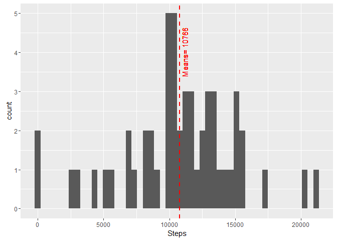

```r
activities<- read.csv(unz(temp,"activity.csv"))
totalStepsPerDay<-aggregate(activities$steps, by=list(activities$date),FUN=sum)
totalStepsPerDay$date<-strptime(totalStepsPerDay$Group.1,"%Y-%m-%d")
mx<-mean(totalStepsPerDay$x,na.rm=T)
qplot( x, data=totalStepsPerDay, xlab="Steps", na.rm=T, bins=50)+geom_histogram(na.rm=T,bins=50)+geom_vline(aes(xintercept=mx),   color="red", linetype="dashed", size=1)+geom_text(aes(x=mx, label=paste("\nMeans=",round(mx,digits=0)), y=4), colour="red", angle=90)
```

Mean of total number of steps taken per day = 10766 steps.

Median of total number of steps taken per day = 10765 steps.

## What is the average daily activity pattern?

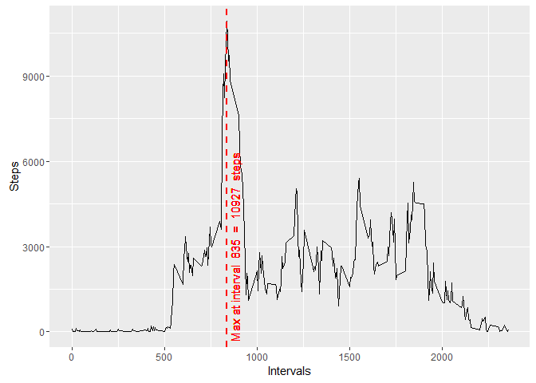

```r
totalStepsPerIntervalBlock<-aggregate(activities$steps, by=list(activities$interval), FUN=sum, na.rm=T, na.action=NULL)
colnames(totalStepsPerIntervalBlock)<-c("Intervals", "Steps")
mx<-totalStepsPerIntervalBlock[which.max(totalStepsPerIntervalBlock$Steps),]

ggplot(totalStepsPerIntervalBlock, aes(Intervals, Steps))+geom_line()+geom_vline(aes(xintercept=mx$Intervals),   color="red", linetype="dashed", size=1)+geom_text(aes(x=mx$Intervals, label=paste("\nMax at interval ",mx$Intervals," = ",mx$Steps, " steps" ), y=3000), colour="red", angle=90)
```

Interval 835 contains the maximum number of steps of 10927

## Imputing missing values

Total number of missing values in dataset = 2304 rows

Preparing a list of candidate values to replace missing values in data set using the mean steps per interval block;

```r
meanStepsPerIntervalBlock<-aggregate(activities$steps,by=list(activities$interval), FUN=mean,na.rm=T, na.action=NULL)
colnames(meanStepsPerIntervalBlock)<-c("Intervals", "Steps")
meanStepsPerIntervalBlock$roundMeanSteps<-round(meanStepsPerIntervalBlock$Steps, digits=0)
```

Replacing the missing values with the candidate values that have been prepared earlier;

```r
cleanUpActivities<-activities
for(i in 1:nrow(cleanUpActivities)){
  if(is.na(cleanUpActivities[i,"steps"])){
    cleanUpActivities[i,"steps"]<-meanStepsPerIntervalBlock[meanStepsPerIntervalBlock$Intervals==cleanUpActivities[i, "interval"],"roundMeanSteps"]
  }
}
```

Plotting the histogram with the cleaned up dataset;

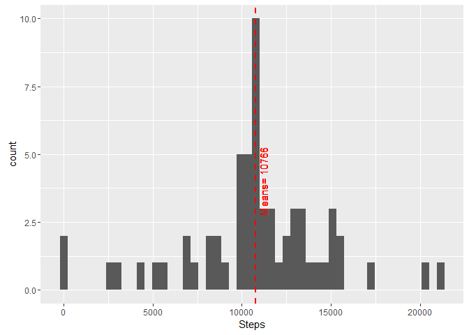

```r
newTotalStepsPerDay<-aggregate(cleanUpActivities$steps, by=list(cleanUpActivities$date),FUN=sum)
newTotalStepsPerDay$date<-strptime(newTotalStepsPerDay$Group.1,"%Y-%m-%d")
mx<-mean(newTotalStepsPerDay$x,na.rm=T)
qplot( x, data=newTotalStepsPerDay, xlab="Steps", na.rm=T, bins=50)+geom_histogram(na.rm=T,bins=50)+geom_vline(aes(xintercept=mx),   color="red", linetype="dashed", size=1)+geom_text(aes(x=mx, label=paste("\nMeans=",round(mx,digits=0)), y=4), colour="red", angle=90)
```

Mean of total number of steps taken per day in the new, cleaned up dataset = 10766 steps.

Median of total number of steps taken per day in the new, cleaned up dataset= 10762 steps.

While there is no significant impact of imputing missing data on the mean but the median value has reduced by 3.

## Are there differences in activity patterns between weekdays and weekends?

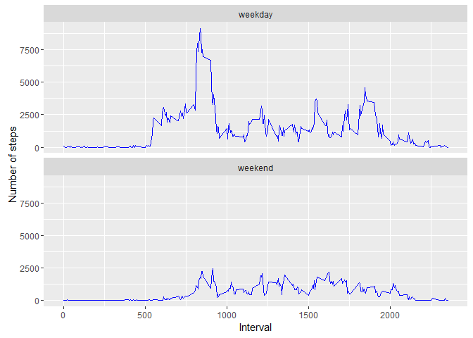

```r
activities$weekstate<-ifelse(weekdays(as.Date(activities$date),abbr=T)!="Sat"&weekdays(as.Date(activities$date),abbr=T)!="Sun","weekday","weekend")


newTotalStepsPerIntervalBlock<-aggregate(activities$steps, by=list(activities$interval, activities$weekstate), FUN=sum, na.rm=T, na.action=NULL)

colnames(newTotalStepsPerIntervalBlock)<-c("interval","weekstate", "steps")


ggplot(newTotalStepsPerIntervalBlock,aes(interval, steps))+geom_line(color="blue")+facet_wrap(~weekstate, ncol=1)+labs(y="Number of steps", x="Interval")
```

```r
#+theme(strip.text=element_text(angle=180))
```